# Franco Lab Cell Count Analysis Percentage 4 Groups

Luuli N Tran

2024-02-04

# Introduction:

The purpose of this notebook is to provide a template for users to perform statistical analysis and visualization on cell counting data resulting from in utero electroporation. This notebook utilizes published data from the paper titled “Notch signaling plays a dual role in regulating the neuron-to-oligodendrocyte switch in the developing dorsal forebrain” (https://doi.org/10.1523/JNEUROSCI.0144-23.2023).

The code in this notebook as well as in the scripts are generic. Meaning, you can change the variables to fit your particular cell counting experiment, such as the name of the markers you counted as well as the treatment groups.

##### How I cell count for in utero electroporation experiments:

This might be different depending on the experiment. Generally, for E15.5-E18.5 electroporations, I image the entire electroporated area in the dorsal pallium. I then use photoshop to divide the image into the columns of the same size spanning the entire electroporated area. The size of the columns don’t typically matter for counting electroporated cells, as in the end we will take the PERCENTAGE of electroporated cells that are positive for a marker. If you are counting the total number of cells per area, then it does matter what size the columns or boxes are.

I use image J’s Cell Count Analysis feature to count cells, and I use an excel spreadsheet to keep track of cell counts. This excel sheet serves as a “map” of the cell counts over the images. The percent of electroporated (EP’d) cells that are marker positive are then added into a separate CSV file that will be used for statistical analysis and visualization using R.

#### Overview of this notebook:

1. Experiment information
2. Read in data
3. Define markers and treatment groups
4. Organize and summarize data
5. Perform statistical analysis
6. Generate bar graphs

# 1. Experiment information

##### ASCL1, NICD+ASCL1, DNRBPJ+ASCL1 E15.5-18.5

To understand whether Notch signaling is cooperateing with ASCL1 for OPC production, I electroporated ASCL1 alone, NICD+ASCL1, or DNRBPJ+ASCL1. NICD overactivates Notch, while DNRBPJ inhibits Notch. I only counted GFP+ cells, then I counted how many of those GFP+ cells are OLIG2+. Then I counted how many of those GFP+ OLIG2+ cells are OLIG2+ PDGFRA+. Finally, I divide the # of OLIG2+ and OLIG2+ PDGFRA+ cells by the # of GFP+ cells and multiply by 100 to give me the % of GFP+ cells that are marker+.

- In utero electroporation of pCIG, ASCL1, NICD, and DNRBPJ plasmids into CD1 mice at E15.5, analysis at E18.5.
- IHC for Olig2 and Pdgfra OPC markers.
- Counted % of GFP+ cells that are OLIG2+ and/or PDGFRA+
- Note: I only counted PDGFRA+ cells for a subset of brains.

# 2. Read in Olig2 Pdgfra cell counts csv file.

##### CSV file info:

To make a csv file you can make it in Excel and then save it as CSV. It is best to keep this csv file containing your data “tidy”, meaning there is a column for each variable, a row for each observation, and each value is stored in its own cell with no units. For more on “tidy” data, read more [here](https://r4ds.had.co.nz/tidy-data.html).

There is a template you can use in the `data/` directory called `cellcountdata_template.csv`, that you can fill out. You’ll need to replace the columns marker1-3 with the markers you are interested it.

#### Read in data

First, we will input the data and variables in this code chunk. These defined variables will be applied to the rest of the code.  
This should be the only code chunk you would change to run the rest of the code.

```r
# DEFINE FILES AND PATHS: ---------------------------------------------------

input_file <- "data/4groups_data/2023-05-01_cd_e15-18_dnrbpj-ascl1-nicd_olig2_pdgfra.csv"
output_dir_tables <- "results/4groups_results/tables/"
output_dir_figures <- "results/4groups_results/figures/"

# Make sure output directory exists, and if it doesn't, create one
if (!dir.exists(output_dir_tables)) {
  dir.create(output_dir_tables, recursive = TRUE)
}

if (!dir.exists(output_dir_figures)) {
  dir.create(output_dir_figures, recursive = TRUE)
}

# DEFINE MARKERS AND CONTROL GROUP: --------------------------------------

# Define markers based on sample sheet columns
markers <- c("olig2", "olig2_pdgfra")

# Define control_group
control_group <- "pcig"
```

Now, we will read in the data and check that everything is correct.

```r
# Read input_file as dataframe and save as object
data <- read.csv(file.path(input_file), stringsAsFactors = FALSE)
```

#### Table containing data

You can see what the data and the columns/rows look like in this scrollable table:

```r
# show data in table
data %>%
  kbl(caption = "Sample Sheet") %>%
  kable_styling(bootstrap_options = "striped", full_width = F) %>%
  scroll_box(height = "300px")
```

Sample Sheet

| treatment | brain_id | olig2 | olig2_pdgfra |
| --- | --- | --- | --- |
| pcig | 1 | 4.550946 | 1.651228 |
| pcig | 2 | 7.956817 | 3.318672 |
| pcig | 3 | 5.122096 | 1.459202 |
| pcig | 4 | 5.783866 | NA |
| pcig | 5 | 3.182215 | NA |
| ascl1 | 1 | 11.867089 | 2.610759 |
| ascl1 | 2 | 10.769231 | 3.478261 |
| ascl1 | 3 | 11.599387 | 2.963720 |
| ascl1 | 4 | 14.220183 | NA |
| nicd_ascl1 | 1 | 19.472617 | 6.135903 |
| nicd_ascl1 | 2 | 17.508754 | 6.503252 |
| nicd_ascl1 | 3 | 28.334786 | 7.236269 |
| nicd_ascl1 | 4 | 19.525268 | NA |
| dnrbpj_ascl1 | 1 | 2.447257 | 1.181435 |
| dnrbpj_ascl1 | 2 | 2.980473 | 1.130524 |
| dnrbpj_ascl1 | 3 | 3.004808 | 1.322115 |

# 3. Define markers and treatment groups

We defined the markers and treatment groups at the beginning of this markdown file.  
Here, we will just check to make sure everything is correct. If they are not correct, check for these in the code chunk where we defined variables and the input file:  
* Make sure the input_file path is correct.  
* Make sure the markers are in quotes and they are written exactly as they are named in the marker columns of the data dataframe.  
* Make sure treatment groups are written exactly as they are written in the “treatment” column of the data dataframe

#### Check markers

```r
print(markers)
```

```
## [1] "olig2"        "olig2_pdgfra"
```

#### Define treatment groups

Change as needed based on your treatment column.

```r
# define all other unique treatments as "mutant"
mutant_groups <- setdiff(unique(data$treatment), control_group)
all_groups <- c(control_group, mutant_groups)

print(control_group)
```

```
## [1] "pcig"
```

```r
print(mutant_groups)
```

```
## [1] "ascl1"        "nicd_ascl1"   "dnrbpj_ascl1"
```

```r
print(all_groups)
```

```
## [1] "pcig"         "ascl1"        "nicd_ascl1"   "dnrbpj_ascl1"
```

# 4. Organize and Summarize data

Summarize the data (mean, standard deviation, n, standard error) using the dataframes created above as another dataframe for each marker combination. Store each measure as its own column as below: * mean_cells = mean * sd_cells = standard deviation * n_cells = n * SE_cells = standard error

##### Note:

Every time you do something repetitive like this, you could make a function that does all the steps for you and all you need to do is put in variables, like below. This makes code more organized and readable.

Since I only counted a subset of brains for olig2_pdgfra, the function below will ignore the NA values.

#### Define function for summarizing data

```r
summ_data_function <- function(data_df, marker_col) {
  data_summ_df <- data_df %>%
    group_by(treatment) %>%
    summarise(
      mean_cells = mean(.data[[marker_col]], na.rm = TRUE),
      sd_cells = sd(.data[[marker_col]], na.rm = TRUE),
      n_cells = sum(!is.na(.data[[marker_col]])),  # Count non-NA values
      SE_cells = sd(.data[[marker_col]], na.rm = TRUE) / sqrt(n_cells)
    ) %>%
    ungroup()

  # Ensure treatment order (control first)
  data_summ_df$treatment <- factor(data_summ_df$treatment, levels = all_groups)
  return(data_summ_df)
}
```

#### Summarize the data for each marker

Here, we will create dataframes for the summarized data for each marker, and save them as .csv files in the ‘results/tables/’ directory.

We will first initiate a list called “summarized_data”. This list is currently empty. But we will fill it with the following for loop, iterating through the “markers” vector that was defined earlier. This for loop goes through each marker in the markers vector, performs the summ_data_function we made earlier, and then stores the result as its own dataframe (data_marker) and then stores that dataframe in the summarized_data list that was originally empty. You can read more about for loops in R [here](https://www.datacamp.com/tutorial/tutorial-on-loops-in-r).

Each dataframe for each summarized dataset will be saved as a .csv file.

```r
# initiate list
summarized_data <- list()

# iterate through each marker and call function
for (marker in markers) {
  summarized_data[[marker]] <- summ_data_function(data, marker)
  print(summarized_data[[marker]])

  # write a csv file for each summarized dataset for each marker
  write.csv(summarized_data[[marker]],
            file.path(
              output_dir_tables, paste0(marker,".csv")),
            row.names = FALSE)

  # Print to let us know that script was completed successfully
  print(paste("Data for", marker, "has been preprocessed."))

}
```

```
## # A tibble: 4 × 5
##   treatment    mean_cells sd_cells n_cells SE_cells
##   <fct>             <dbl>    <dbl>   <int>    <dbl>
## 1 ascl1             12.1     1.48        4    0.740
## 2 dnrbpj_ascl1       2.81    0.315       3    0.182
## 3 nicd_ascl1        21.2     4.84        4    2.42
## 4 pcig               5.32    1.76        5    0.786
## [1] "Data for olig2 has been preprocessed."
## # A tibble: 4 × 5
##   treatment    mean_cells sd_cells n_cells SE_cells
##   <fct>             <dbl>    <dbl>   <int>    <dbl>
## 1 ascl1              3.02   0.436        3   0.252
## 2 dnrbpj_ascl1       1.21   0.0992       3   0.0573
## 3 nicd_ascl1         6.63   0.560        3   0.323
## 4 pcig               2.14   1.02         3   0.590
## [1] "Data for olig2_pdgfra has been preprocessed."
```

# 5. Perform statistical analysis

This function uses if/else conditions to determine which test to use for group comparisons. To learn more about if/else statements, go [here](https://www.geeksforgeeks.org/r-if-else-statement/).

#### Define stats test function

```r
# Define stats test function: **************************************************
stats_test_4_groups <- function(data_df, marker_col, control_group, mutant_groups) {
  # Check that the variable is numeric
  variable_data <- data_df[[marker_col]]
  if (!is.numeric(variable_data)) {
    stop("The specified variable is not numeric.")
  }

  # Check that all the groups exist
  all_groups <- c(control_group, mutant_groups)
  # Make a function to extract values of each group and then store in group_data
  group_data <- lapply(all_groups, function(group)
    variable_data[data_df$treatment == group])

  # Check if any group has no data
  if (any(sapply(group_data, length) == 0)) {
    stop("No data found for one or more groups.")
  }

  # Test for normality (Shapiro-Wilk test)
  shapiro_results <- lapply(group_data, shapiro.test)
  names(shapiro_results) <- all_groups

  # Print Shapiro-Wilk test results
  for (group in all_groups) {
    cat(paste("Shapiro test for", group, "p-value:", shapiro_results[[group]]$p.value, "\n"))
  }

  # Test for equality of variances (Levene's test)
  levene_test <- leveneTest(variable_data ~ data_df$treatment)
  cat(paste("Levene test p-value:", levene_test$`Pr(>F)`[1], "\n"))

  # Determine which statistical test to use
  all_normal <- all(sapply(shapiro_results, function(res) res$p.value > 0.05))
  equal_variances <- levene_test$`Pr(>F)`[1] > 0.05

  if (all_normal) {
    if (equal_variances) {
      test_result <- aov(variable_data ~ data_df$treatment)
      test_used <- "One-way ANOVA"  # Normal distribution & equal variances
    } else {
      test_result <- oneway.test(variable_data ~ data_df$treatment, var.equal = FALSE)
      test_used <- "Welch's ANOVA"  # Normal distribution but unequal variances
    }
  } else {
    test_result <- kruskal.test(variable_data ~ data_df$treatment)
    test_used <- "Kruskal-Wallis test"  # Non-normal distribution
  }

  # Print results
  cat(paste("Test used:", test_used, "\n"))
  print(summary(test_result))

  # Compute group means
  group_means <- sapply(group_data, mean, na.rm = TRUE)

  # Return results as a list
  stats_test_result <- list(
    Normality_Results = shapiro_results,
    Variance_Result = levene_test,
    Test_Used = test_used,
    Test_Result = test_result,
    Group_Means = group_means
  )

  return(stats_test_result)
}
```

#### Perform stats tests by calling function

Here, we will create an output .txt file to store the stats results for each marker.

Similar as before, we will now initiate a new list called “stats_results”, and iterate through the markers vector again and performs stats test for each marker. The results will be printed below.

```r
# Define output file
stats_output_file <- file.path(output_dir_tables, "stats_results.txt")

# Open connection to write stats results in the output
sink(stats_output_file)

# Initiate list
stats_results <- list()

# Iterate through each marker and call function to perform stats tests
for (marker in markers) {
  stats_results[[marker]] <- stats_test_4_groups(data,
                                                 marker,
                                                 control_group,
                                                 mutant_groups)
  # print message and results to .txt file
  cat(paste("\nStats results for", marker, ":\n"))
  print(stats_results[[marker]])
}
# Close the sink connection after the 'for loop' above is done
sink()
```

You can look at the contents of the stats_results and look at specific results by stating the marker dataframe.

```r
print(stats_results$olig2)
```

```
## $Normality_Results
## $Normality_Results$pcig
##
##  Shapiro-Wilk normality test
##
## data:  X[[i]]
## W = 0.97404, p-value = 0.9005
##
##
## $Normality_Results$ascl1
##
##  Shapiro-Wilk normality test
##
## data:  X[[i]]
## W = 0.88859, p-value = 0.3766
##
##
## $Normality_Results$nicd_ascl1
##
##  Shapiro-Wilk normality test
##
## data:  X[[i]]
## W = 0.78911, p-value = 0.08408
##
##
## $Normality_Results$dnrbpj_ascl1
##
##  Shapiro-Wilk normality test
##
## data:  X[[i]]
## W = 0.78267, p-value = 0.07376
##
##
##
## $Variance_Result
## Levene's Test for Homogeneity of Variance (center = median)
##       Df F value Pr(>F)
## group  3  0.8027 0.5161
##       12
##
## $Test_Used
## [1] "One-way ANOVA"
##
## $Test_Result
## Call:
##    aov(formula = variable_data ~ data_df$treatment)
##
## Terms:
##                 data_df$treatment Residuals
## Sum of Squares           780.8333   89.4561
## Deg. of Freedom                 3        12
##
## Residual standard error: 2.730326
## Estimated effects may be unbalanced
##
## $Group_Means
## [1]  5.319188 12.113972 21.210356  2.810846
```

## Post hoc Tukey’s test

For both marker datasets, the function used One-way ANOVA. We can perform post hoc Tukey’s tests to get pairwise comparisons. In the Tukey Results you can access the p-values for pairwise comparisons as well as the p-value for one-way ANOVA, which I will use to display on the barplot later.

#### Define function for performing post hoc tukey’s test

```r
posthoc_tukey_test <- function(data_df, marker_col, group_col) {

  # Check that the specified columns exist
  if (!(marker_col %in% colnames(data_df)) || !(group_col %in% colnames(data_df))) {
    stop("One or more specified columns do not exist in the dataset.")
  }

  # Remove rows with NA values in the selected columns
  data_clean <- na.omit(data_df[, c(marker_col, group_col)])

  # Maure sure the grouping variable is a factor
  data_clean[[group_col]] <- as.factor(data_clean[[group_col]])

  # Perform one-way ANOVA
  model <- aov(as.formula(paste(marker_col, "~", group_col)), data = data_clean)

  # Extract ANOVA summary
  summary_posthoc <- summary(model)

  # Extract ANOVA p-value
  anova_p_value <- summary_posthoc[[1]]$`Pr(>F)`[1]

  # Perform Tukey HSD test for pairwise comparisons
  tukey_results <- TukeyHSD(model, conf.level = 0.95)

  # Extract p-values
  tukey_p_values <- tukey_results[[group_col]][,"p adj"]

  # Format p-values with up to 10-digits
  formatted_p_values <- signif(tukey_p_values, digits = 10)

  # Plot Tukey HSD results
  plot(tukey_results, las = 2)

  # Return results as a list
  return(list(
    "ANOVA_p_value" = anova_p_value,
    "Tukey_P_Values" = formatted_p_values,
    "Tukey_Summary" = tukey_results
  ))
}
```

#### Call function to perform post hoc tukey’s test

Here, we will create an output .txt file to store the post hoc tukey results.  
Simialr to before, we will initiate a list called posthoc_tukey_results. Then we will iterate through each marker in the markers vector to perform post hoc tukey and save the results in the list posthoc_tukey-results

```r
# Define output file
posthoctukey_output_file <-
  file.path(output_dir_tables, "posthoctukey_results.txt")

# Open connection to write stats results in the output
sink(posthoctukey_output_file)

# Initate list
posthoc_tukey_results <- list()

# Iterate through markers vector
for (marker in markers) {
  posthoc_tukey_results[[marker]] <- posthoc_tukey_test(data,
                                                        marker,
                                                        "treatment")
  # print message and post hoc results to .txt file
  cat(paste("\nPost hoc tukey results for", marker, ":\n"))
  print(posthoc_tukey_results[[marker]])
}
```

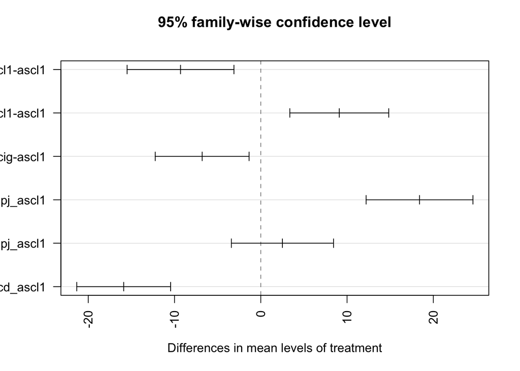

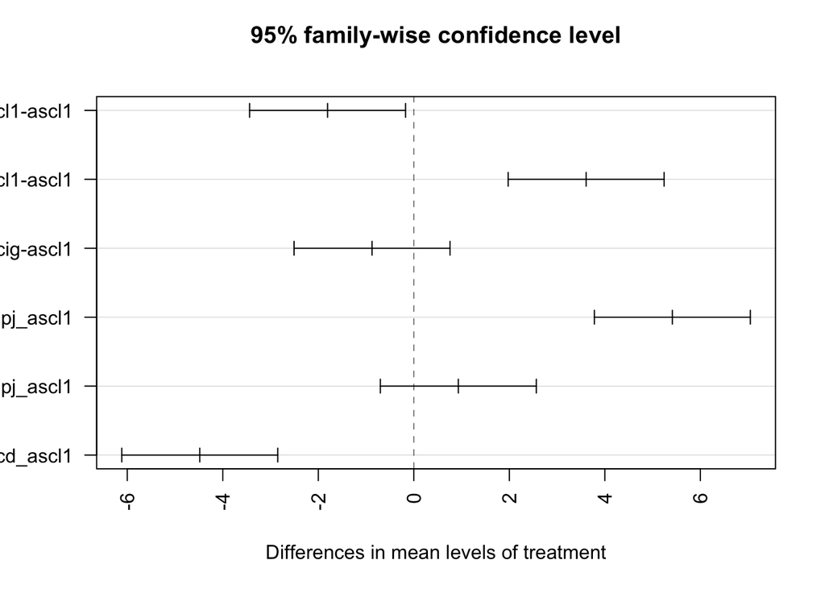

```r
# close connection
sink()

# print message to let us know the script ran successfully
print("Stats tests were performed successfully and saved in results/tables/")
```

```
## [1] "Stats tests were performed successfully and saved in results/tables/"
```

Again, you can access the post hoc tukey results

```r
print(posthoc_tukey_results$olig2)
```

```
## $ANOVA_p_value
## [1] 3.302903e-06
##
## $Tukey_P_Values
##      dnrbpj_ascl1-ascl1        nicd_ascl1-ascl1              pcig-ascl1
##            3.738269e-03            2.450702e-03            1.370440e-02
## nicd_ascl1-dnrbpj_ascl1       pcig-dnrbpj_ascl1         pcig-nicd_ascl1
##            7.092221e-06            6.045052e-01            8.450806e-06
##
## $Tukey_Summary
##   Tukey multiple comparisons of means
##     95% family-wise confidence level
##
## Fit: aov(formula = as.formula(paste(marker_col, "~", group_col)), data = data_clean)
##
## $treatment
##                               diff        lwr        upr     p adj
## dnrbpj_ascl1-ascl1       -9.303126 -15.494237  -3.112016 0.0037383
## nicd_ascl1-ascl1          9.096384   3.364529  14.828239 0.0024507
## pcig-ascl1               -6.794784 -12.232499  -1.357070 0.0137044
## nicd_ascl1-dnrbpj_ascl1  18.399510  12.208400  24.590621 0.0000071
## pcig-dnrbpj_ascl1         2.508342  -3.411492   8.428176 0.6045052
## pcig-nicd_ascl1         -15.891168 -21.328883 -10.453454 0.0000085
```

# 6. Generate bar graphs

Now we would like to visualize the data by graphing them. I prefer graphing cell count data as bar graphs with dots representing each data point overlaid, as well as error bars. But the fun thing about R’s ggplot2 package is you can make many different kinds a bar graphs. ggpalot’s layering affect makes these graphs easily customizable. Read more about the ggplot2 package and the types of graphs you can make [here](https://ggplot2.tidyverse.org/articles/ggplot2.html).

We will make bar graphs which will compare the % of EP’d cells (y axis) across treatments (pcig vs mutant groups) (x axis).

I will layer the plot like this:  
* geom_col() showing the mean for each treatment, * geom_errorbar() showing the difference between the mean and standard error in positive and negative directions, * geom_dotplot() showing each individual value of each treatment.  
* I also like to put the stats test result and the test used on the graph, which you can remove later.

You can change the colors of the lines/fill/dots in the graph in R as well. Often times, I will set default colors for graphs in R, but I will save the graph as a PDF file and I can further edit the colors to my liking in Adobe Illustrator.

Since we are making 2 graphs, which can be repetitive, I will define a function that I can use over and over again.

#### Define function for plotting bar graph

```r
create_barplot_4_groups <- function(data_summ,
                                    data_marker,
                                    treatment_col = "treatment",
                                    marker_col = "marker",
                                    title = "Title",
                                    positions = NULL,
                                    test_used,
                                    p_value,
                                    fill_colors = NULL,
                                    dotsize_value = 1,
                                    fixed_divisor = 40,
                                    y_label = "% of EP'd cells") {

  scaleFUN <- function(x) sprintf("%.1f", x)

  # Default position order
  if (is.null(positions)) {
    positions <- unique(data_marker[[treatment_col]])
  }

  # Default fill colors if not defined
  if (is.null(fill_colors)) {
    fill_colors <- scales::hue_pal()(length(positions))
  }

  # Calculate max value of y-axis and add buffer (for annotation and y-axis scale)
  max_marker_value <- max(data_marker[[marker_col]], na.rm = TRUE) * 1.1

  # Define binwidth based on range of marker values/y axis
  binwidth_value <- (max(data_marker[[marker_col]], na.rm = TRUE) -
                     min(data_marker[[marker_col]], na.rm = TRUE)) / fixed_divisor

  # Plot
  barplot <- ggplot(data_summ,
                    aes(x = !!sym(treatment_col),
                        y = mean_cells)) +
    geom_col(width = 0.5,
             aes(fill = !!sym(treatment_col)),
             color = 'black',
             size = 0.25) +
    geom_errorbar(aes(ymin = mean_cells - SE_cells,
                      ymax = mean_cells + SE_cells),
                  width = 0.3,
                  size = 0.25) +
    geom_dotplot(data = data_marker,
                 aes(x = !!sym(treatment_col),
                     y = !!sym(marker_col),
                     fill = !!sym(treatment_col)),
                 binaxis = 'y',
                 stackdir = 'center',
                 dotsize = dotsize_value,
                 binwidth = binwidth_value,
                 show.legend = FALSE) +
    theme_classic(base_size = 10) +
    ylab(y_label) +
    scale_x_discrete(limits = positions) +
    theme(
      panel.background = element_blank(),
      panel.grid = element_blank(),
      axis.line = element_line(size = 0.25,
                               color = rgb(0, 0, 0, max = 255)),
      axis.text.x = element_text(colour = 'black', angle = 45, hjust = 1),
      axis.text.y = element_text(hjust = 1, colour = 'black'),
      axis.title.x = element_blank(),
      aspect.ratio = 2 / 1,
      legend.key.size = unit(0.7, "line"),
      text = element_text(size = 10),
      plot.title = element_text(size = 10)) +
    scale_y_continuous(expand = c(0, 0), labels = scaleFUN, limits= c(0, max_marker_value)) +
    scale_fill_manual(values = fill_colors,
                      name = "",
                      labels = positions) +
    ggtitle(title) +
    theme(legend.position = "none") +
    annotate("text", x = median(1:length(positions)),
             y = max_marker_value * 0.95,
             label = paste(test_used, "\n", format(p_value, digits = 3)),
             size = 3, hjust = 0.5)

  return(barplot)
}
```

#### Define colors

Choose custom colors. Colors are assigned according to the order of the treatment groups.

```r
custom_colors <- c('#bcbcbc', '#f4bfbd', '#e590a0', '#c4586f')
```

#### Call function to generate bar graphs

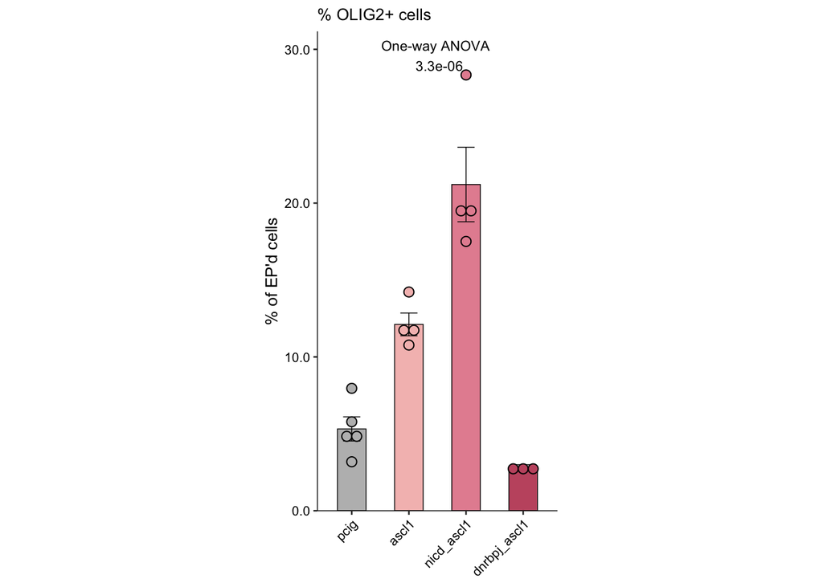

```
## [1] "olig2 barplot generated and saved in results/"
```

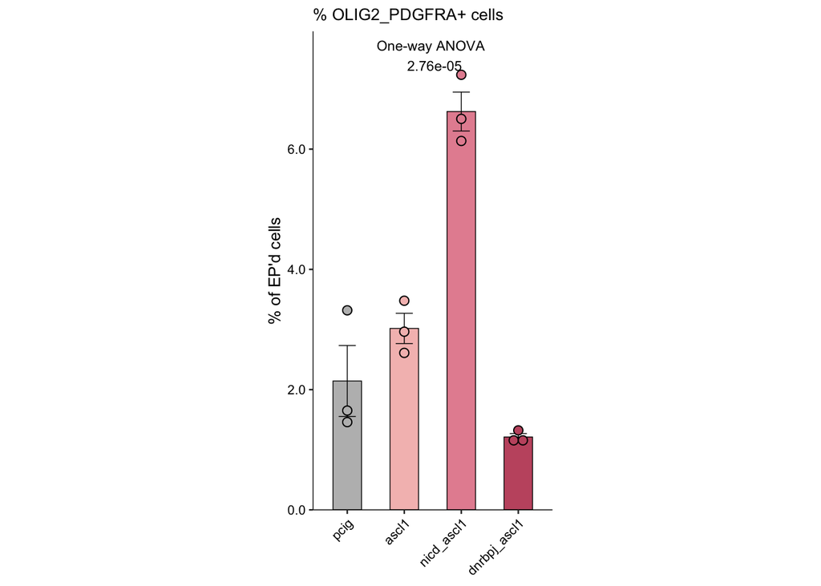

```
## [1] "olig2_pdgfra barplot generated and saved in results/"
```

```r
# Iterate through each marker and generate plots
for (marker in markers) {

  # Extract marker cell count data
  data_marker <- data %>%
    select(treatment, brain_id, all_of(marker))

  # Extract summarized data
  data_summ <- summarized_data[[marker]]

  # Define order of treatments on barplot
  data_summ$treatment <- factor(data_summ$treatment,
                                levels = c(control_group, mutant_groups))
  data_marker$treatment <- factor(data_marker$treatment,
                                  levels = c(control_group, mutant_groups))

  # Extract stats test results
  test_results <- stats_results[[marker]]
  posthoc_tukey_test_results <- posthoc_tukey_results[[marker]]

  # Generate the barplot
  barplot <- create_barplot_4_groups(
    data_summ = data_summ,
    data_marker = data_marker,
    marker_col = marker,
    title = paste0("% ", toupper(marker), "+ cells"),
    test_used = test_results$Test_Used,
    p_value = posthoc_tukey_test_results$ANOVA_p_value,
    fill_colors = custom_colors
  )

  # Print barplots
  print(barplot)

  # Save barplots as PDF files
  # Remove #'s to save. I commented out this code so I don't save over previously saved graphs

  #ggsave(filename = file.path(output_dir_figures, paste0(marker, "_barplot.pdf"),
         #plot = barplot,
         #width = 5,
         #height = 5) # Adjust width and height as needed

  print(paste(marker, "barplot generated and saved in results/"))
}
```